# JSM 2026 Recap

Notes and highlights from the Joint Statistical Meetings

Jessica Minnier

CDSSR, Knight Cancer Institute, OHSU, Portland, OR

August 12, 2026

## JSM Award Session

[figure not shown]

Miguel Marino (OHSU Family Medicine; 2026 ASA Award Fellow) and Motomi Mori (St. Jude)

## Staying Relevant in the Age of AI

- Be a **useful human collaborator** (not just consultant) that brings problem solving skills, creativity, deep stats and data knowledge
- **Identify and show when AI is wrong** but accept it is here to stay
- Be **visible in the research community**, engage, ask questions, show up, teach workshops, establish trust ("Not on our to do list, but so important" -- Manisha Desai, Stanford)
- Embrace the tools, grow and learn, and **don't be left behind**

We have value! Make sure everyone knows it.

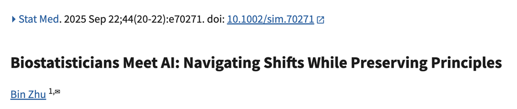

Zhu (2025). *Biostatisticians Meet AI: Navigating Shifts While Preserving Principles.* Stat Med 44:e70271. [doi:10.1002/sim.70271](https://doi.org/10.1002/sim.70271)

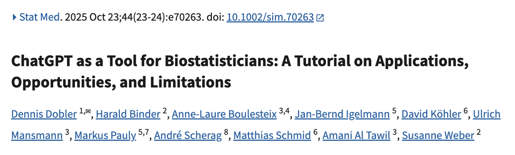

Dobler et al. (2025). *ChatGPT as a Tool for Biostatisticians: A Tutorial on Applications, Opportunities, and Limitations.* Stat Med 44:e70263. [doi:10.1002/sim.70263](https://doi.org/10.1002/sim.70263)

[figure not shown]

Grambow et al. (2025). *Integrating large language models in biostatistical workflows for clinical and translational research.* J Clin Transl Sci 9:e131. [doi:10.1017/cts.2025.10064](https://doi.org/10.1017/cts.2025.10064)

## Strong Statistical Voice

[figure not shown]

[figure not shown]

Pomann et al. (2026). *Enhancing Team Science by Training Collaborative Biostatisticians to have a Strong Statistical Voice.* J Stat Theory Pract 20:13. [doi:10.1007/s42519-025-00522-7](https://doi.org/10.1007/s42519-025-00522-7)

quantsprogram.com

## Engagement in the Knight

- Retreat discussion topic
- 2026–27 KCI/CDCB Faculty Research Exchange series
- Knight Research Day
- AI in Biology sessions
- Knight Retreat
- Knight Research Seminars (it's our job to learn the science, it's all relevant)

## Thank you

*Slides made with the assistance of Claude Code*